# Decomposition of human ageing

```r
library(hsc19)
library(Seurat)
library(ggplot2)
```

## Summary

This vignette decomposes HSC transcriptomes from [a large scale resource on human ageing](https://www.nature.com/articles/s41591-025-03716-5) into nineteen gene regulatory programs. It demonstrates the basic use of the `decompose` and `associate` functions, and reproduces figure S8 from the manuscript.

## Data preparation

**Input into the decompose function is bulk RNA-seq data of HSCs/MPPs.** Here, these bulk expression signatures are computed by subsetting a single cell data set to HSCs/MPPs and computing pseudobulks. In other scenarios (cf. Venetoclax vignette), bulk RNA-seq data of FACS-sorted HSCs/MPPs is used. The workflows used in these vignettes assume integer count data, and apply appropriate normalization routines.

**The first two steps of data preparation are to download the Furer et al. single cell RNA-seq data, subset to HSC/MPP and and create pseudobulks.** The result of this step is made available in the folder data_ageing, and step 1 and 2 of data preparation are not run by default. Click to expand and make the code visible.**

### Step 1 (not run): Download data from [CellXGene](https://cellxgene.cziscience.com/collections/5542eeb0-96ef-4ab9-95ea-eb6abc178461)

```bash
wget -O furer_ultima.h5ad https://datasets.cellxgene.cziscience.com/fd9e6b84-4687-44cb-a61e-1b261c05c414.h5ad
wget -O furer_illumina.h5ad https://datasets.cellxgene.cziscience.com/00414a7b-5aba-4c51-ad1e-d6caa6b1ebf3.h5ad
```

### Step 2 (not run): Create patient-level pseudobulks of HSCs - shown for ultima data

```python
import scanpy as sc
import numpy as np
from scipy import sparse
import pandas as pd
ad = sc.read("furer_ultima.h5ad")
ad = ad[(ad.obs["cell state"] == "HSC_MPP") & (ad.obs["disease"] == "normal")]


# Extract donor IDs
donor_ids = ad.obs["donor_id"].values

# Get unique donors
unique_donors = np.unique(donor_ids)

# Create pseudobulks
pseudobulk_list = []

for donor in unique_donors:
    print(donor + "\n")
    # Select cells for this donor
    donor_mask = donor_ids == donor
    donor_counts = ad[donor_mask].X
    # Sum counts across cells
    if sparse.issparse(donor_counts):
        summed_counts = np.array(donor_counts.sum(axis=0)).flatten()
    else:
        summed_counts = donor_counts.sum(axis=0)
    pseudobulk_list.append(summed_counts)

pseudobulk_matrix = pd.DataFrame(
    np.vstack(pseudobulk_list),
    index=unique_donors,
    columns=ad.var_names
)

pseudobulk_matrix.transpose().to_csv("Furer_et_al_ultima_pseudobulks.csv.gz", compression='gzip')
```

### Step 3: Load pseudobulks in R, create Seurat object

The following code block creates a Seurat object of pseudobulks and performs normalization. It also prepares a metadata frame with metadata for each column (sample) from the Seurat object.

```r
illumina_pseudobulks <- read.csv("data_ageing/Furer_et_al_illumina_pseudobulks.csv.gz", row.names = 1)
ultima_pseudobulks <- read.csv("data_ageing/Furer_et_al_ultima_pseudobulks.csv.gz", row.names = 1)
common <- intersect(rownames(illumina_pseudobulks), rownames(ultima_pseudobulks))
union_id <- union(colnames(illumina_pseudobulks), colnames(ultima_pseudobulks))
combined_pseudobulks <- matrix(0,nrow = length(common), ncol = length(union_id), dimnames = list(common, union_id))
for (i in colnames(illumina_pseudobulks)) combined_pseudobulks[,i] <- illumina_pseudobulks[common, i]
for (i in colnames(ultima_pseudobulks)[!colnames(ultima_pseudobulks) %in% colnames(illumina_pseudobulks)]) combined_pseudobulks[,i] <- combined_pseudobulks[,i] + ultima_pseudobulks[common, i]

metadata <- read.csv("data_ageing/patient_level_metadata.csv")
rownames(metadata) <- paste0("WIS_blood_aging_", metadata$Individual.ID)
metadata_use<- metadata[colnames(combined_pseudobulks),]
S <- CreateSeuratObject(counts = combined_pseudobulks, names.field = 4, meta.data = metadata_use)
S <- NormalizeData(S, normalization.method = "LogNormalize", scale.factor = 10000)
```

```
#> Normalizing layer: counts
```

```r
S <- subset(S, cells = rownames(metadata))
S <- FindVariableFeatures(S, verbose=F)
S <- ScaleData(S, verbose=F)
S <- RunPCA(S, verbose=F)
metadata_final <- metadata[colnames(S),]
```

## Decompose data into GRPs

The decompose function is the central piece of the hsc 19 package. It takes a seurat object (or a count matrix) and decomposes into estimated activities of gene programs defined by a real-valued matrix of gene weights. By default, the GRPs from the manuscript are used. Alternatively, a matrix of genes x programs can be provided as parameter `loadings`. See function documentation for full specification of parameters and return values.

```r
result <- decompose(s = S)
```

```
#>
#> Run on 120 samples. On the overlapping gene set of 742 genes, 19 programs explain 11.8 % of the gene expression variance in your data. For comparison, 19 principal components explain 83.1 %
```

## Compute p-values: Association of GRPs with age (Figure S8B)

Only associations with FDR < 0.1 (Benjamini-Hochberg across the GRPs) are shown, as in the manuscript.

The `associate` function, in its basic use, computes p-value associations between programs and a feature/outcome of interest from a metadata frame. Rows in the metadata frame should correspond to columns from the seurat object used for decomposition. The below example computes p values for the association between (estimated) program activities and the metadata variable “age”.

There are different versions of `associate`, for numeric, binary and survival outcomes.

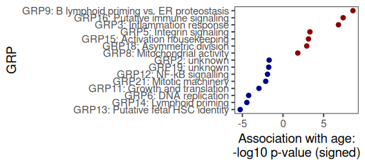

```r
pvalues <- associate_numeric_outcome(result, metadata_final, "age", run.ML = F)$p.values

pvalues <- subset(pvalues, grepl("Factor_", factor_id))
pvalues$fdr <- p.adjust(pvalues$p_outcome, "fdr")
pvalues$show_value <- -log10(pvalues$p_outcome)
factor_levels <- get_factor_columns(result)
pvalues$factor_id <- factor(pvalues$factor_id, levels = factor_levels)
pvalues <- merge(pvalues, factor_annotation)

pvalues$xval <- with(pvalues, show_value * sign_outcome * multiply_with)
ylab <- sprintf("%s: %s", gsub("Factor_", "GRP", factor_annotation$factor_id), factor_annotation$factor_label); names(ylab) <- factor_annotation$factor_id

a <- qplot(x =  xval, y = reorder(factor_id,xval), color = as.factor(sign_outcome* multiply_with), data = subset(pvalues, fdr < 0.1)) +
  xlab("Association with age:\n-log10 p-value (signed)") + scale_y_discrete(labels = ylab, name = "GRP") + theme_bw(base_size = 14) + theme(panel.grid = element_blank()) + scale_color_manual(values = c("-1" = "darkblue", "1"= "darkred"), guide =F)
 print(a)
```

## Display correlation of GRP3 and Ageing (Figure S8A)

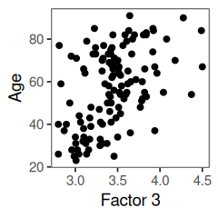

```r
b <- qplot(result@result[ "Factor_3", ], metadata_final$age) +theme_bw(base_size = 14) + theme(panel.grid = element_blank()) + xlab("Factor 3") + ylab("Age") + scale_x_continuous(limits = c(2.8,4.5), oob=scales::squish)
print(b)
```

## Construct a GRP based ageing clock (Figure S8C)

First, run 10-fold CV with the factors to predict age

```r
set.seed(3719)
factors <- rownames(result@result)[-1]
sets <- rep(1:10, length.out = ncol(S))
sh <- sample(1:ncol(S))
features <- t(result@result)[sh,-1]
response <- metadata_final[colnames(result), "age"][sh]
predicted.linear <- rep(NA, ncol(S))

for (i in 1:10) {
  train <- features[sets != i, ]
  test <- features[sets == i,]
  linear <- lm(response ~ . , data = data.frame(response = response[sets!=i], train))
  predicted.linear[sets == i] <- predict(linear, newdata = as.data.frame(test))
}
```

## General machine learning from the transcriptome (Figure S8C)

Besides computing p-values, the `associate` function can also run and compare several black box machine learning strategies to predict the outcome/feature of interest from the transcriptome, beyond GRPs. It runs principal component regression, LASSO regression and differential expression testing followed by LASSO or linear regression on top DE features. ML is performed inside a 10-fold cross-validation loop. The best GRP is selected independently in each cross validation loop. The function can also compare GRPs to further, prespecified predictors (e.g. gene signatures from literature); see the remaining vignettes and the function documentation for these parameters, and documentation of the return value.

```r
set.seed(3719)
ml <- associate_numeric_outcome(result, metadata_final, "age", other.predictors = NULL, run.ML = T, replicates = 10, cores = 10, genelists = NULL)
```

Finally, make a plot that compares the predictive power of GRP3 (squared correlation on all samples, not cross-validated), the linear model from all GRPs (10-fold CV), and the best transcriptome-wide black-box machine learning model (principal component regression, LASSO, or DE-based regression; 10-fold CV, mean over replicates). Models built on GRPs are not eligible for the “full transcriptome” bar.

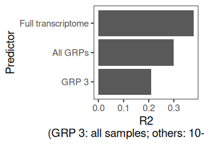

```r
ml_models <- c("R2.lm.de", "R2.lasso.de", "R2.lm.pcr", "R2.lasso.pcr")
r2s <- data.frame(
  what = factor(c("GRP 3", "All GRPs", "Full transcriptome"),levels = c("GRP 3", "All GRPs", "Full transcriptome")),
  R2 = c(cor(result@result[ "Factor_3", ], metadata_final$age)^2,cor(predicted.linear, response)^2, max(ml$r.squares[ml_models], na.rm=T) )
)

d <- ggplot(aes(x = what, y = R2), data = r2s) + geom_col() + coord_flip()  +theme_bw(base_size = 14) + theme(panel.grid = element_blank()) + xlab("Predictor") + ylab("R2\n(GRP 3: all samples; others: 10-fold CV)")
print(d)
```